# Arima_Model

# Load the dataset

```r
rm(list=ls())

library(tidyquant)
tesla_data <- getSymbols(Symbols = "TSLA", src = "yahoo", from = "2000-01-01",
                        to = Sys.Date(), auto.assign = FALSE)
```

[output not shown]

```r
tesla_data <- Cl(tesla_data)
```

# STOCK CHARTING

In order to begin analysing stock, here’s the charting plus some technical indicators such as Simple Moving Average (20 and 100), Bollinger bands (20, sd = 1), Relative Strength Index (14 days), and Moving Average Convergence Divergence (12, 25) as the technical analysis before forecasting.

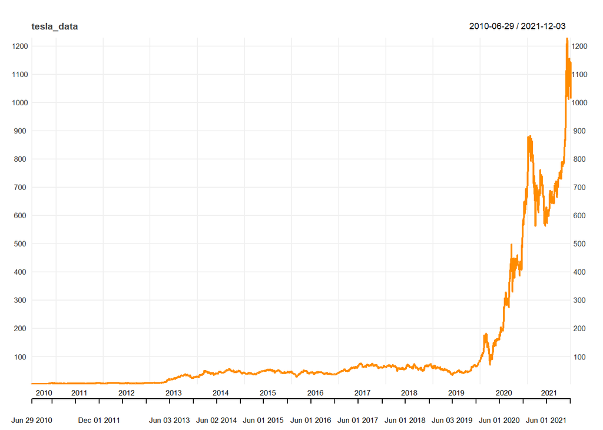

```r
chart_Series(tesla_data, col = "black")
```

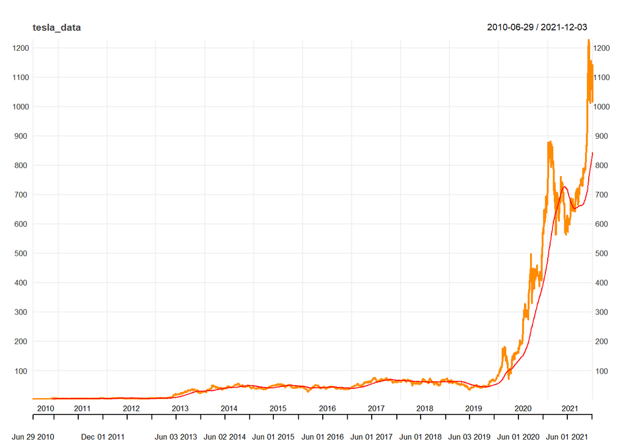

```r
add_SMA(n = 100, on = 1, col = "red")
```

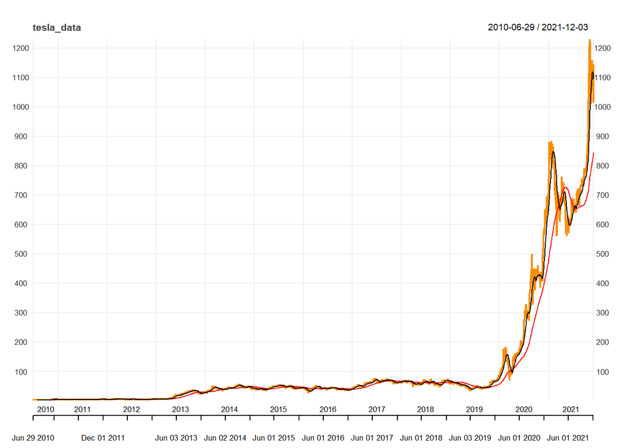

```r
add_SMA(n = 20, on = 1, col = "black")
```

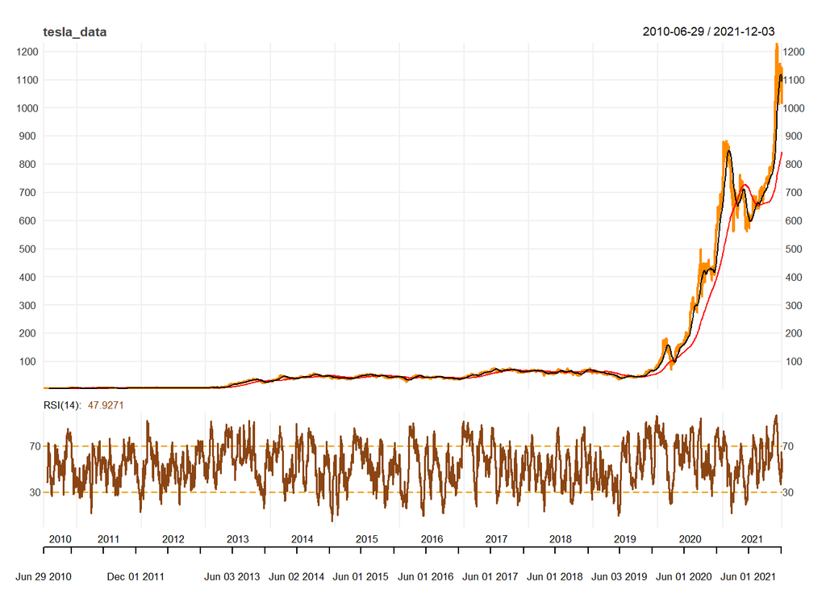

```r
add_RSI(n = 14, maType = "SMA")
```

[figure not shown]

```r
add_BBands(n = 20, maType = "SMA", sd = 1, on = -1)
```

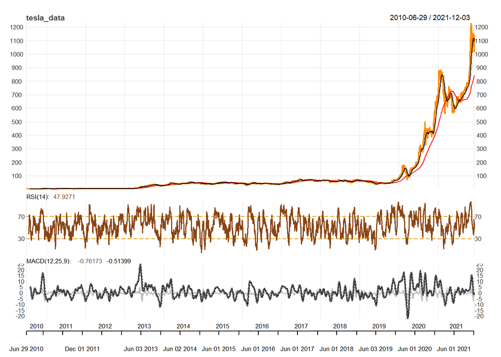

```r
add_MACD(fast = 12, slow = 25, signal = 9, maType = "SMA", histogram = TRUE)
```

# Checking whether data is Stationary or Not

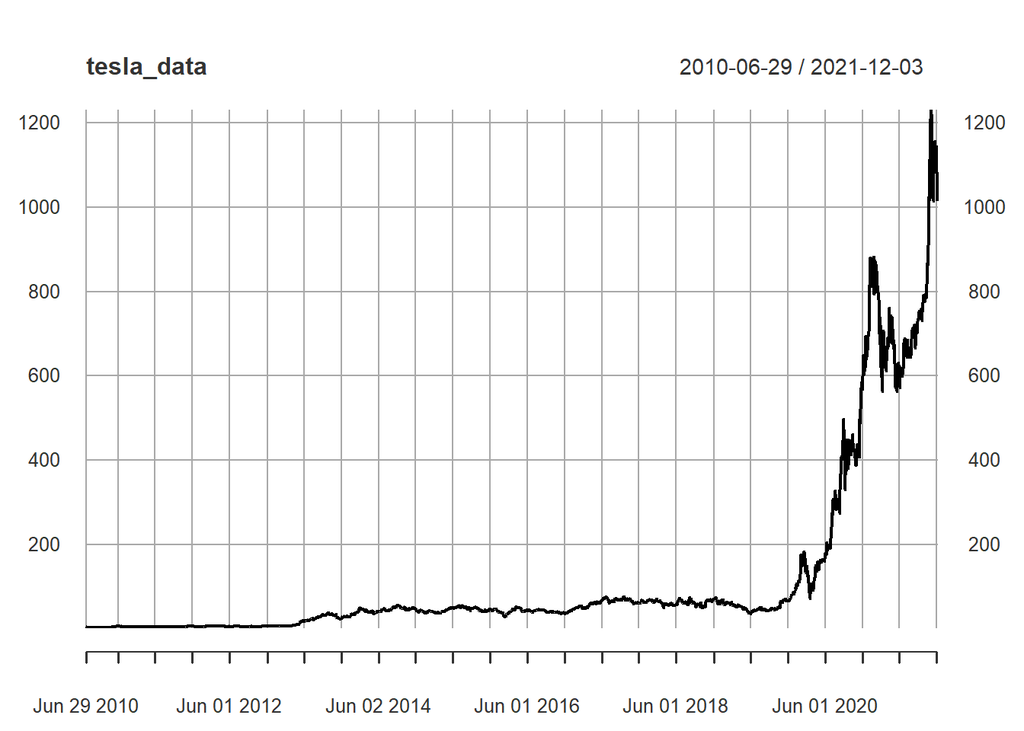

```r
plot(tesla_data)
```

# Transforming the data with Log

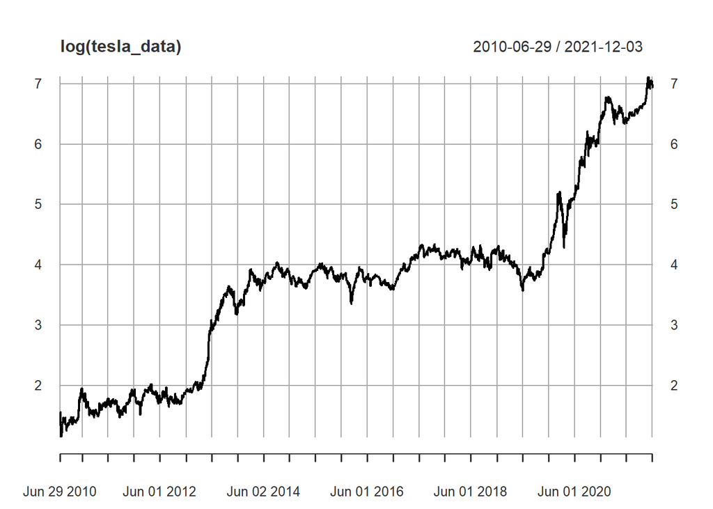

```r
plot(log(tesla_data))
```

As the data has been log-transformed, we can clearly see that the series shows some upward and downward trend in a given time interval. The stock also consist of some volatility and swing. These are the signs that the stock price movement is non-stationary. Matter of fact, most of financial data is non-stationary (in which the mean, variance, autocorrelation, are not constant over time), but most of them follow random walk model with or without drift (RWM or RWD), This is due to the stock tend to having trend and inconstant variance and mean in a given period. Given that we can guess that its a random walk, which means the current value (price) is equal to its price at time (t - 1) plus a random shock (White Noise), hence we should difference the data with certain lag in order to fit ARIMA model as we’ll see later

# Checking the Autocorrelation and Partial Autocorrelation Function

This is where we check whether the current value is correlated to the past/yesterdays value.

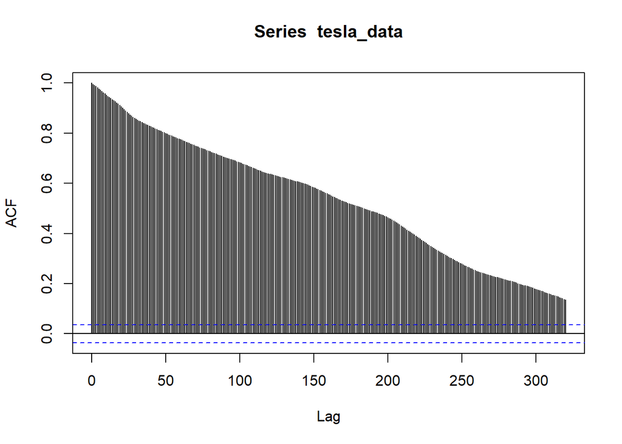

```r
acf_tesla = acf(tesla_data, lag.max = 320)
```

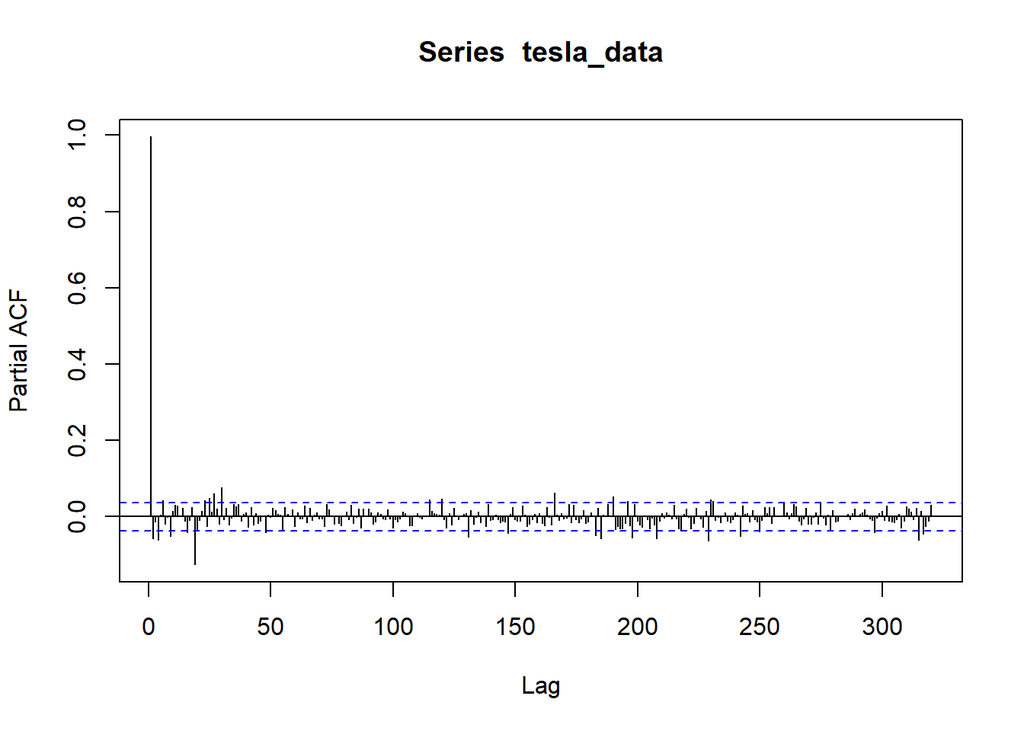

```r
pacf_tesla=pacf(tesla_data, lag.max = 320)
```

# Making the Data Stationary

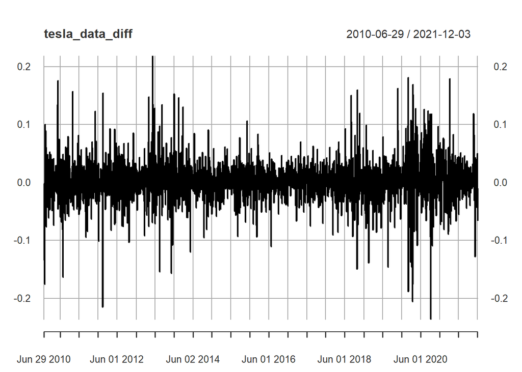

```r
tesla_data_diff= diff(log(tesla_data), lag =1) # Adjusting the mean

tesla_data_diff = na.locf(tesla_data_diff, na.rm = TRUE,
                      fromLast = TRUE) # Replacing missing values

plot(tesla_data_diff)
```

# Testing the Stationarity using Augmented Dickey Fuller Test. Null Hypothesis = Non-Satationary Alternative Hyp = Stationary

```r
library(tseries)
adf <- adf.test(tesla_data, alternative = c("stationary", "explosive"),
                k = 0)
adf
```

```
##
##  Augmented Dickey-Fuller Test
##
## data:  tesla_data
## Dickey-Fuller = 1.0693, Lag order = 0, p-value = 0.99
## alternative hypothesis: stationary
```

Hence as p-value>0.05, we cannot RJ null and conclude that our undifferentiated tesla stock data is non-Stationary.

```r
adf <- adf.test(tesla_data_diff, alternative = c("stationary", "explosive"),
                k = 0)
adf
```

```
##
##  Augmented Dickey-Fuller Test
##
## data:  tesla_data_diff
## Dickey-Fuller = -53.441, Lag order = 0, p-value = 0.01
## alternative hypothesis: stationary
```

AS the p-value<0.05, we can reject null and conclude that our differentiated tesla stock data is stationary.

# Plotting ACF and PACF Curves

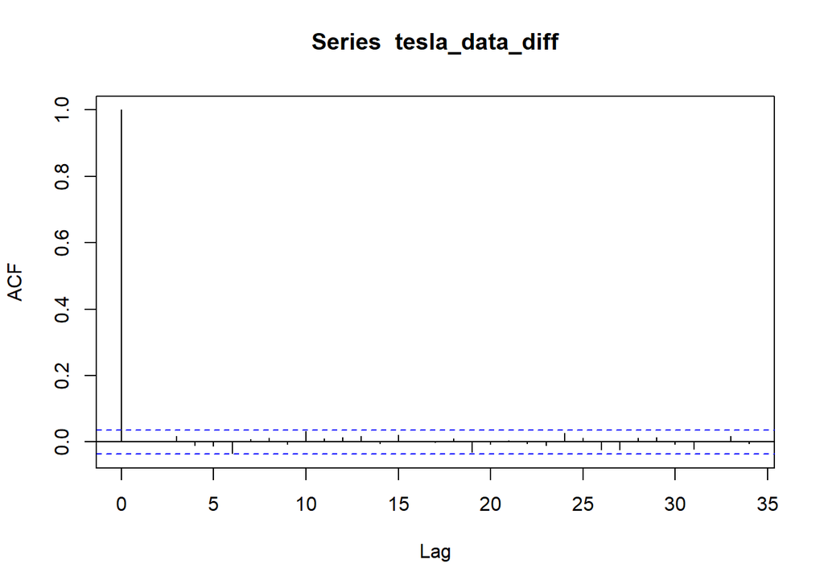

```r
acf_tesla  = acf(tesla_data_diff) # Determining the value of autoregressive AR(P)
```

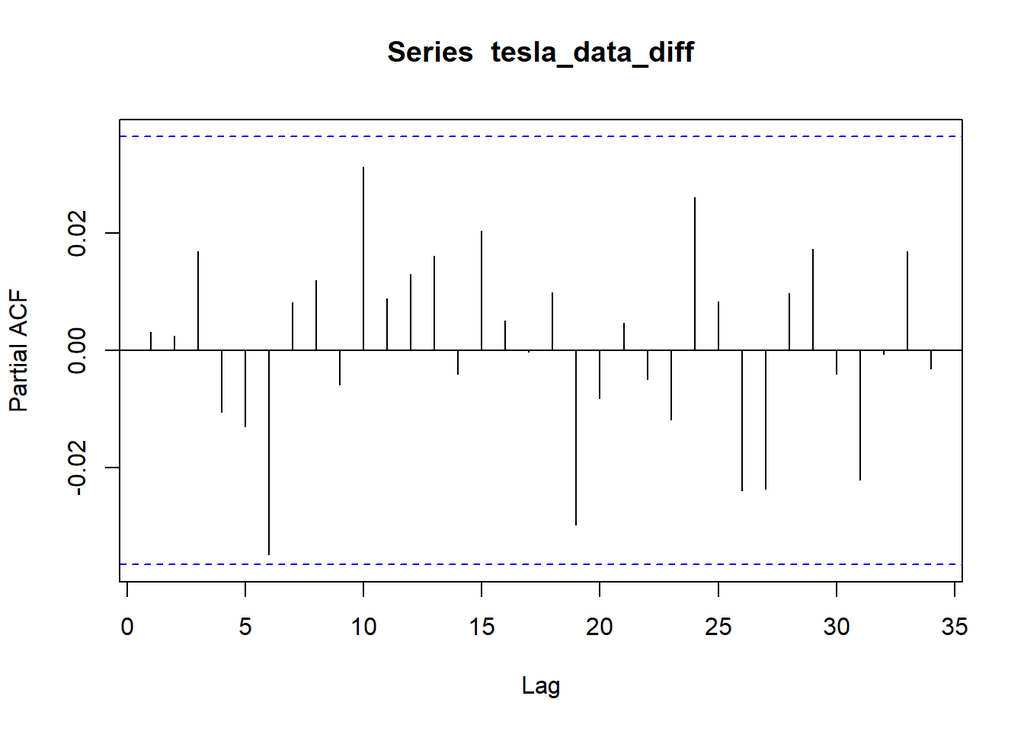

```r
pacf_tesla = pacf(tesla_data_diff) # Determining the value of moving avg MA(p)
```

# Build the ARIMA Model

```r
library(forecast)
set.seed(100)
arima_model <- auto.arima(tesla_data_diff, stationary = TRUE, ic = c("aicc", "aic", "bic"),
                          trace = TRUE)
```

```
##
##  Fitting models using approximations to speed things up...
##
##  ARIMA(2,0,2) with non-zero mean : Inf
##  ARIMA(0,0,0) with non-zero mean : -11098.86
##  ARIMA(1,0,0) with non-zero mean : -11095.9
##  ARIMA(0,0,1) with non-zero mean : -11096.88
##  ARIMA(0,0,0) with zero mean     : -11092.84
##  ARIMA(1,0,1) with non-zero mean : Inf
##
##  Now re-fitting the best model(s) without approximations...
##
##  ARIMA(0,0,0) with non-zero mean : -11098.86
##
##  Best model: ARIMA(0,0,0) with non-zero mean
```

```r
summary(arima_model)
```

```
## Series: tesla_data_diff
## ARIMA(0,0,0) with non-zero mean
##
## Coefficients:
##         mean
##       0.0019
## s.e.  0.0007
##
## sigma^2 estimated as 0.00124:  log likelihood=5551.43
## AIC=-11098.86   AICc=-11098.86   BIC=-11086.93
##
## Training set error measures:
##                         ME       RMSE        MAE  MPE MAPE     MASE        ACF1
## Training set -2.621109e-15 0.03520671 0.02401454 -Inf  Inf 0.688105 0.003178749
```

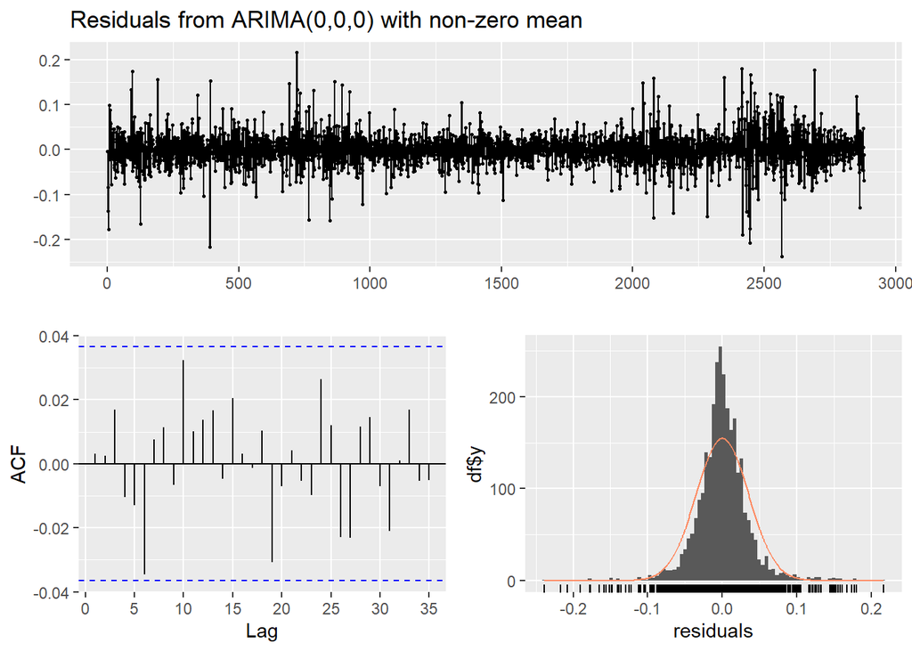

```
##
##  Ljung-Box test
##
## data:  Residuals from ARIMA(0,0,0) with non-zero mean
## Q* = 8.8644, df = 9, p-value = 0.4499
##
## Model df: 1.   Total lags used: 10
```

```r
checkresiduals(arima_model) ###diagnostic cheking
```

# Fitting the model and forecasting

```r
arima <- arima(tesla_data_diff, order = c(0, 0, 0))
summary(arima)
```

```
##
## Call:
## arima(x = tesla_data_diff, order = c(0, 0, 0))
##
## Coefficients:
##       intercept
##          0.0019
## s.e.     0.0007
##
## sigma^2 estimated as 0.00124:  log likelihood = 5551.43,  aic = -11098.86
##
## Training set error measures:
##                         ME       RMSE        MAE  MPE MAPE     MASE        ACF1
## Training set -2.621109e-15 0.03520671 0.02401454 -Inf  Inf 0.688105 0.003178749
```

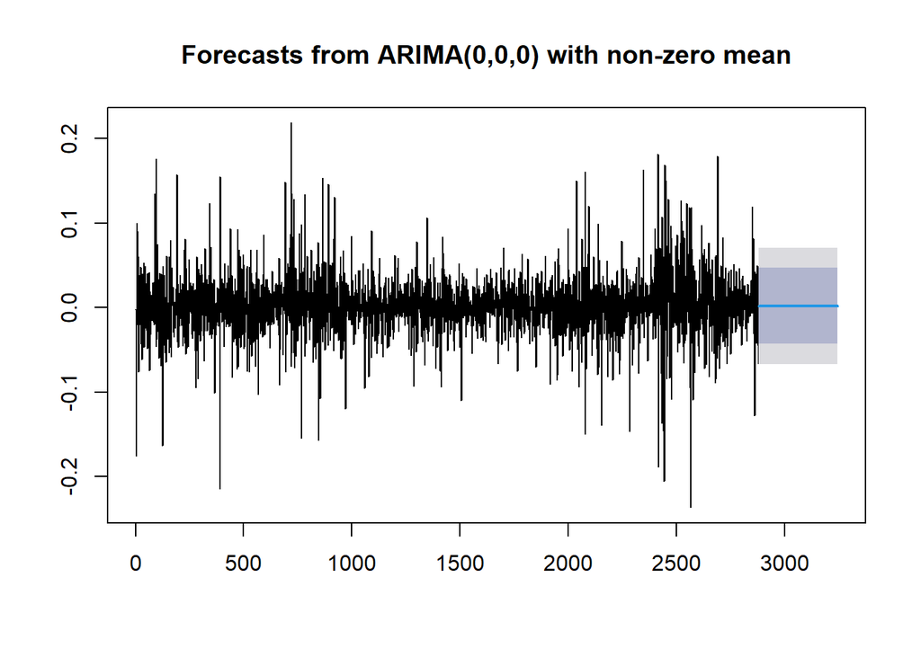

```r
forecast_tesla <- forecast(arima, h = 365)
plot(forecast_tesla)
```

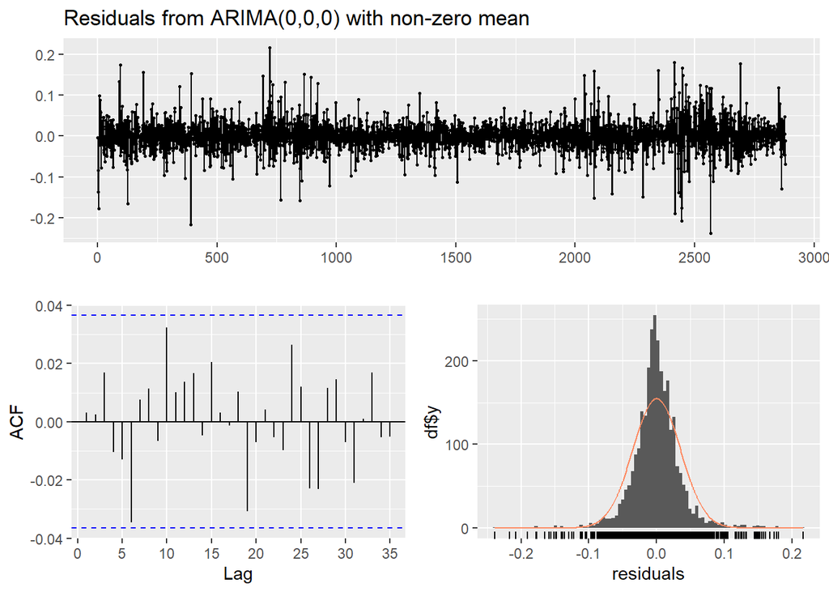

```
##
##  Ljung-Box test
##
## data:  Residuals from ARIMA(0,0,0) with non-zero mean
## Q* = 8.8644, df = 9, p-value = 0.4499
##
## Model df: 1.   Total lags used: 10
```

```r
checkresiduals(arima)
```

```r
arima1 = arima(log(tesla_data[1:2650]), order=c(0,1,0))
summary(arima1)
```

```
##
## Call:
## arima(x = log(tesla_data[1:2650]), order = c(0, 1, 0))
##
##
## sigma^2 estimated as 0.001251:  log likelihood = 5094.47,  aic = -10186.94
##
## Training set error measures:
##                       ME       RMSE        MAE        MPE      MAPE      MASE
## Training set 0.001911531 0.03535576 0.02400614 0.04552196 0.8199207 0.9996472
##                     ACF1
## Training set 0.008357883
```

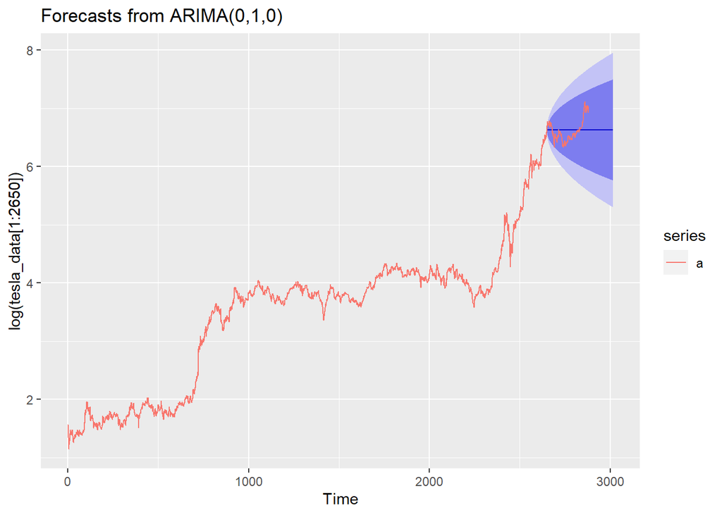

```r
forecast_1=forecast(arima1, h=365)
a = ts(log(tesla_data))
forecast_1 %>% autoplot()+autolayer(a)
```

```r
tesla_data[2857]
```

```
##            TSLA.Close
## 2021-11-01    1208.59
```

```r
arima1 = arima(log(tesla_data[1:2857]), order=c(0,1,0))
summary(arima1)
```

```
##
## Call:
## arima(x = log(tesla_data[1:2857]), order = c(0, 1, 0))
##
##
## sigma^2 estimated as 0.001239:  log likelihood = 5505.39,  aic = -11008.78
##
## Training set error measures:
##                      ME       RMSE       MAE        MPE      MAPE      MASE
## Training set 0.00193726 0.03519782 0.0239656 0.04452605 0.7863403 0.9996728
##                     ACF1
## Training set 0.003511915
```

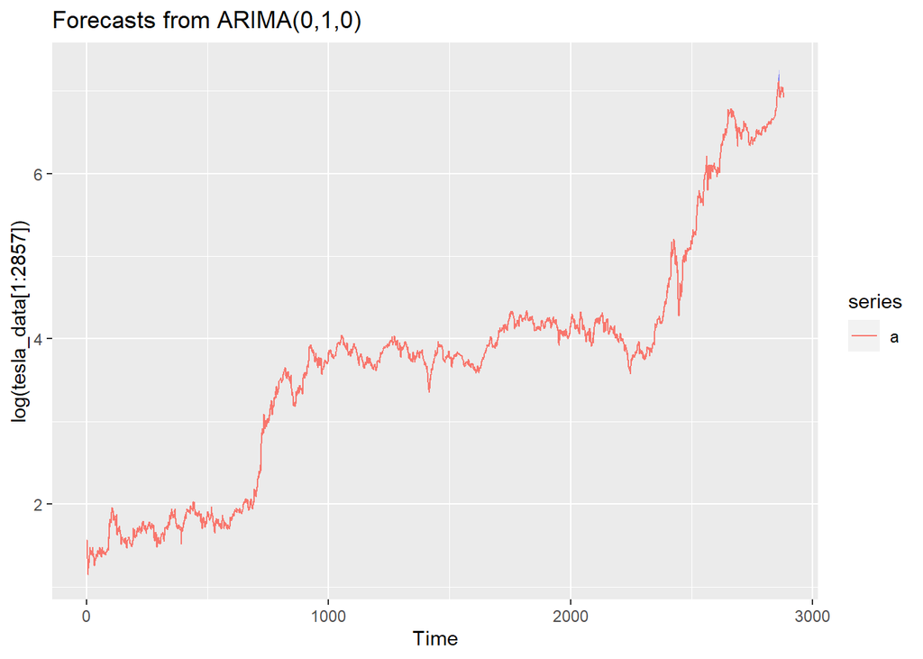

```r
forecast_1=forecast(arima1, h=7)
a = ts(log(tesla_data))
forecast_1 %>% autoplot()+autolayer(a)
```